# 2019 Love Live! Song Popularity Poll Results

by [randhash](https://www.reddit.com/user/randhash/)

18 July 2019

# Introduction

## Acknowledgements

This document displays Love Love! song popularity results from [an online poll](https://www.reddit.com/r/SchoolIdolFestival/comments/c9htvz/hello_ive_made_a_poll_that_ranks_the_popularity/), which was created by a-large-bee aka [idolfestivals](https://idolfestivals.tumblr.com/) and was open from July 5 to 8, 2019. The OP released the poll results in [this reddit post](https://www.reddit.com/r/SchoolIdolFestival/comments/cb70qb/2019_song_popularity_poll_results/). Many thanks to the OP for creating the opportunity to gauge the opinions of the wider Love Live! community.

## Some general poll statistics

In total, the poll received 734 ballots. However, the poll recorded 719 ballots after removing ballots whose respondents did not answer at least one question (e.g. the ballot was blank). As indicated by the OP in the results document, the poll was disseminated online through [the SchoolIdolFestival subreddit](https://www.reddit.com/r/SchoolIdolFestival/) and [Tumblr](https://idolfestivals.tumblr.com/).

Out of the 28 questions in the poll, 13 questions were related to Love Live! School Idol Project, 13 questions were related to Love Live! Sunshine!!, and 2 questions were related to PERFECT Dream Project.

## Author Notes

The motivation for this document was to visualize the poll results in a cleaner format. I take no credit for the poll and have merely used its results to make plots. I would also appreciate any feedback on the data visualization and presentation. Any feedback on the original poll should be directed to the OP.

In this document, each question is accompanied by a bar plot of its responses and a table containing background information on the responses. The table contains three statistics for the given question:

- Number of ballots: the number of ballots received for the question (equivalent to the number of respondents who answered the question),
- Number of votes: the number of votes received for the question (since a ballot could contain multiple votes for a given question if the question allowed multiple selections),
- Vote limit: the maximum number of votes allowed for the given question per respondent.

Where relevant, the bars in the bar plot are colored according to a color legend. For the purpose of this color coding, all unnamed subgroups are referred to as a “small group” of the associated larger group. For example, the artist of the song “Manatsu wa Dare no Mono?” would count as “Aqours small group” because the combination of Dia and Ruby is not officially named (technically the name is “Inferno Phoenix,” but this is beside the point).

# Section 1: Love Live! School Idol Project

## 1. Which are your favorite µ’s songs from Love Live! School Idol Project season 1?

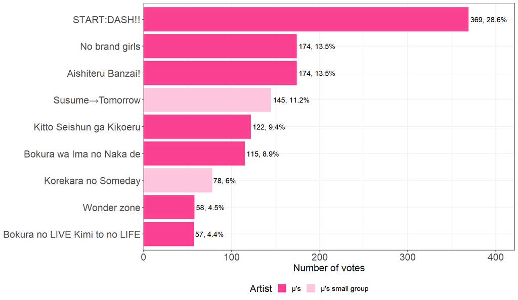

| Number of ballots: | 704 |
| --- | --- |
| Number of votes: | 1292 |
| Vote limit: | 2 |

## 2. Which are your favorite µ’s songs from Love Live! School Idol Project Season 2?

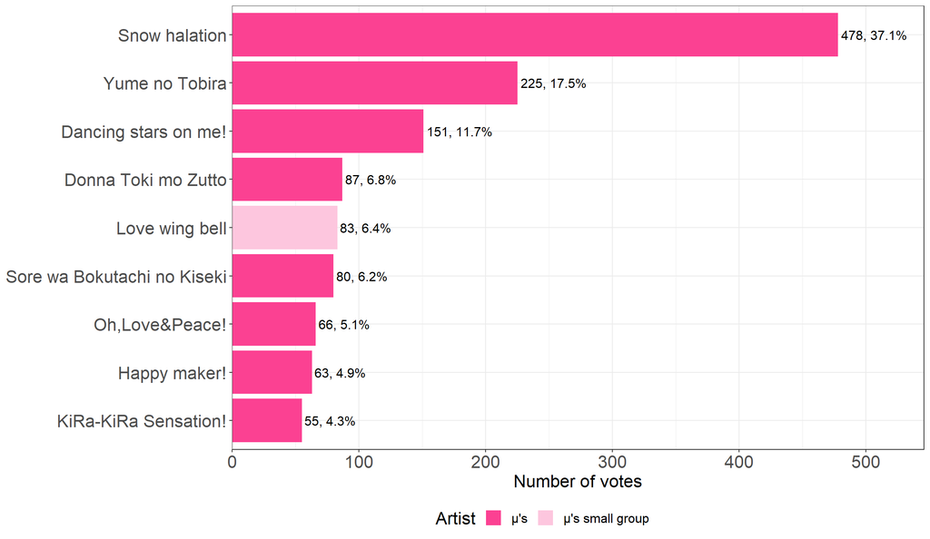

| Number of ballots: | 707 |
| --- | --- |
| Number of votes: | 1288 |
| Vote limit: | 2 |

## 3. Which are your favorite µ’s songs from Love Live! The School Idol Movie?

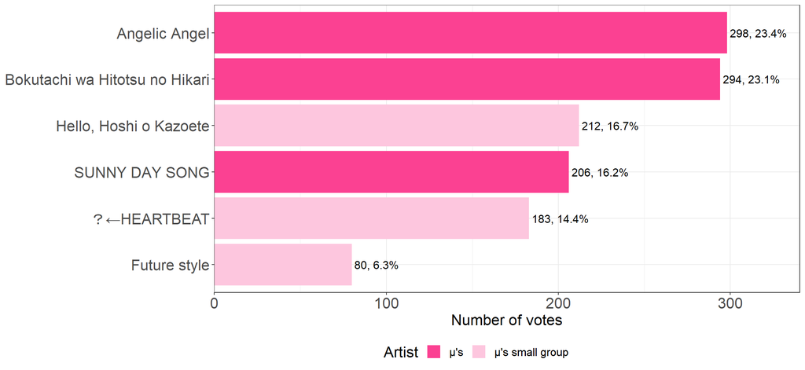

| Number of ballots: | 700 |
| --- | --- |
| Number of votes: | 1273 |
| Vote limit: | 2 |

## 4. Which are your favorite non-insert µ’s songs?

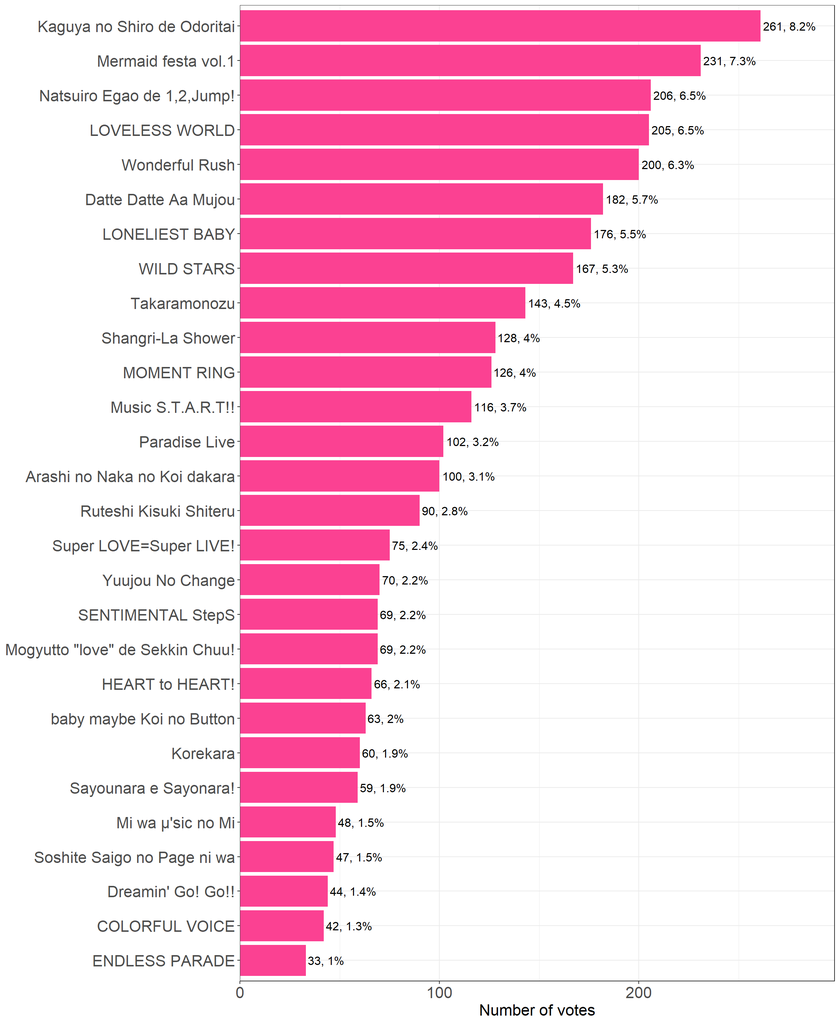

| Number of ballots: | 705 |
| --- | --- |
| Number of votes: | 3178 |
| Vote limit: | 6 |

## 5. Which are your favorite BiBi songs?

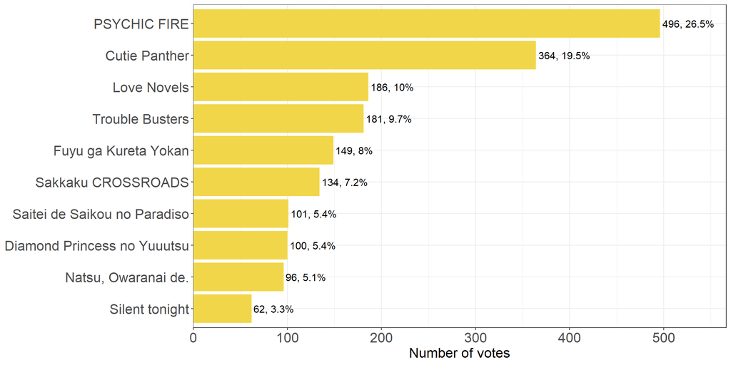

| Number of ballots: | 704 |
| --- | --- |
| Number of votes: | 1869 |
| Vote limit: | 3 |

## 6. Which are your favorite lily white songs?

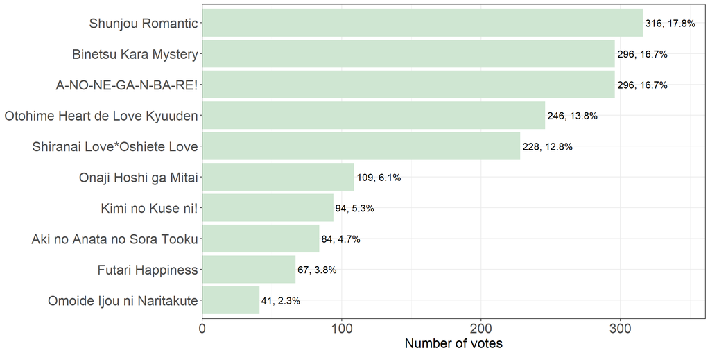

| Number of ballots: | 676 |
| --- | --- |
| Number of votes: | 1777 |
| Vote limit: | 3 |

## 7. Which are your favorite Printemps songs?

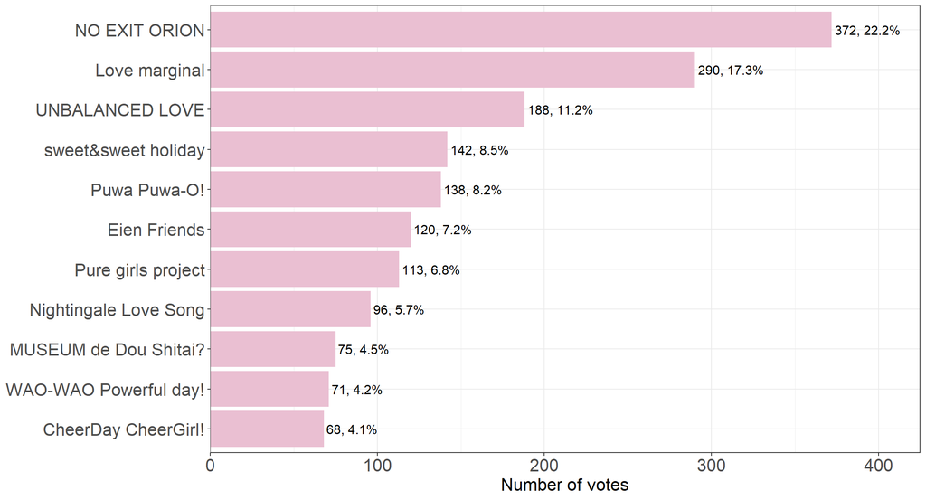

| Number of ballots: | 666 |
| --- | --- |
| Number of votes: | 1673 |
| Vote limit: | 3 |

## 8. Which are your favorite small group songs?

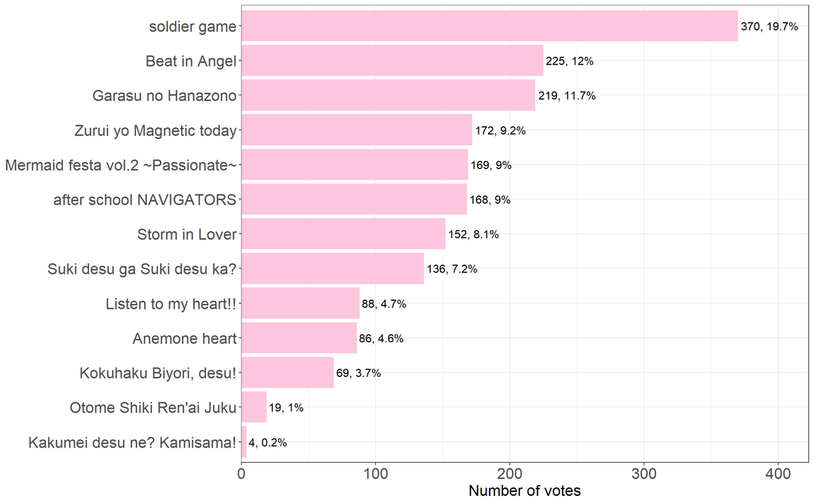

| Number of ballots: | 692 |
| --- | --- |
| Number of votes: | 1877 |
| Vote limit: | 3 |

## 9. Which are your favorite solo songs?

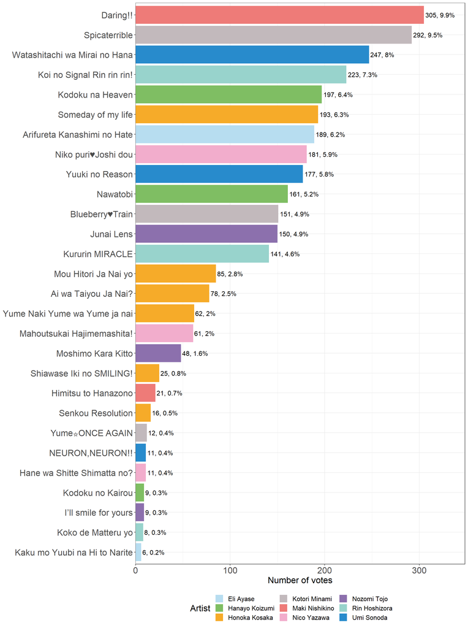

| Number of ballots: | 690 |
| --- | --- |
| Number of votes: | 3069 |
| Vote limit: | 5 |

## 10. Which is your favorite A-RISE song?

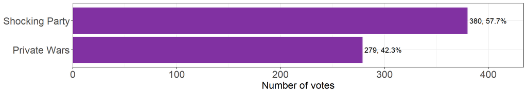

| Number of ballots: | 659 |
| --- | --- |
| Number of votes: | 659 |
| Vote limit: | 1 |

## 11. Out of every song from this section, which is your favorite?

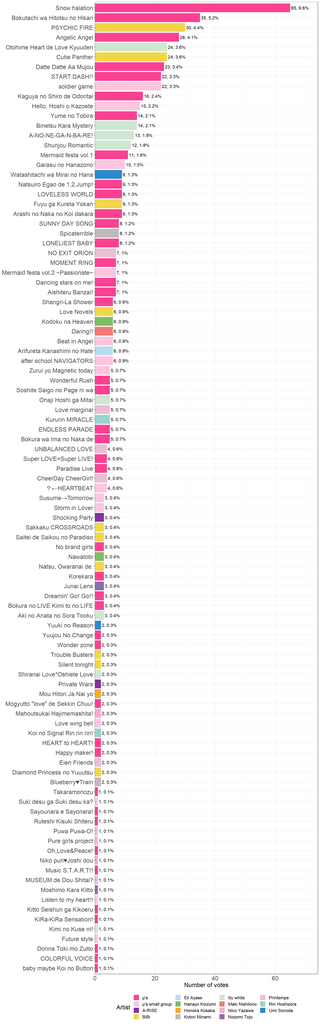

| Number of ballots: | 676 |
| --- | --- |
| Number of votes: | 676 |
| Vote limit: | 1 |

## 12. Which is your favorite MV?

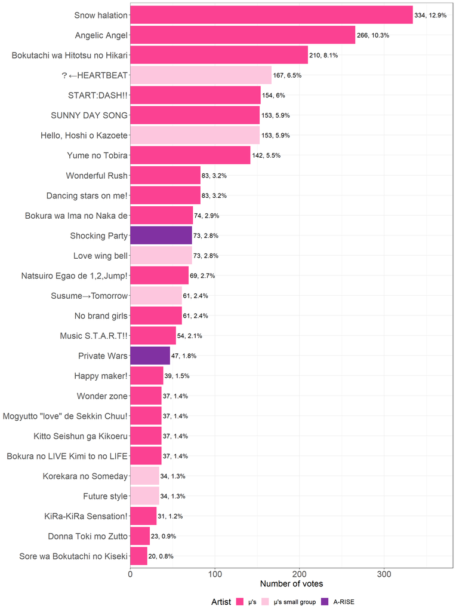

| Number of ballots: | 629 |
| --- | --- |
| Number of votes: | 2586 |
| Vote limit: | 6 |

## 13. Which µ’s member is your favorite singer?

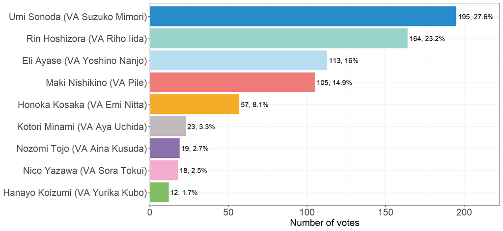

| Number of ballots: | 706 |
| --- | --- |
| Number of votes: | 706 |
| Vote limit: | 1 |

# Section 2: Love Live! Sunshine!!

## 1. Which are your favorite Aqours songs from Love Live! Sunshine!! season 1?

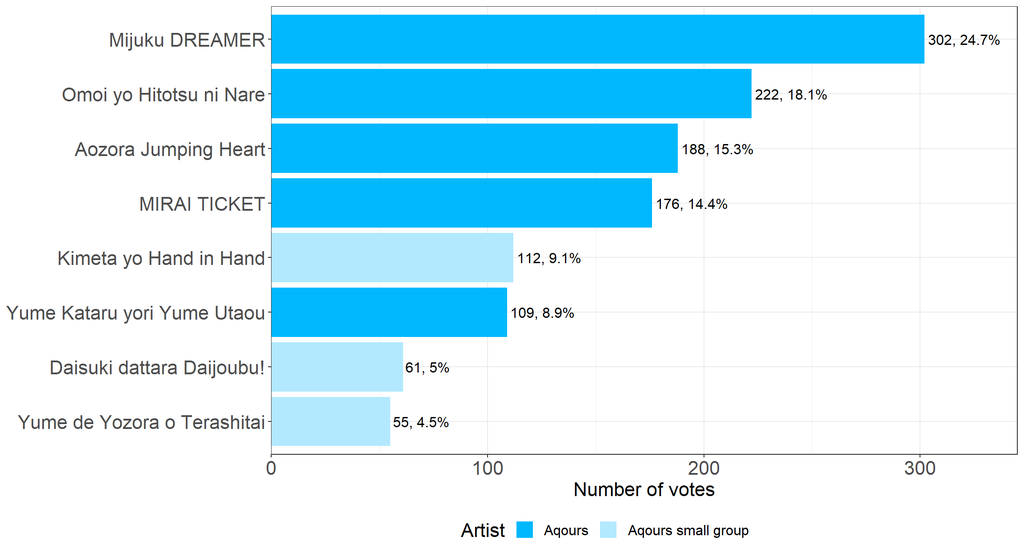

| Number of ballots: | 677 |
| --- | --- |
| Number of votes: | 1225 |
| Vote limit: | 2 |

## 2. Which are your favorite Aqours songs from Love Live! Sunshine!! season 2?

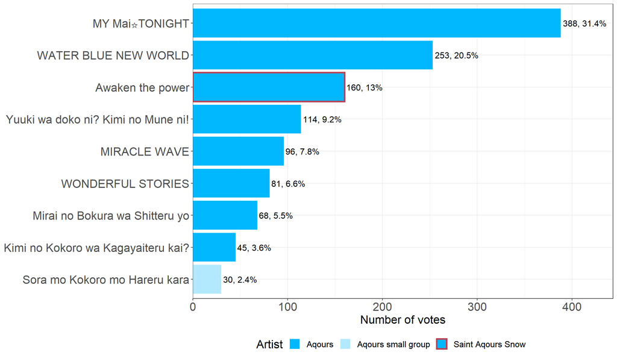

| Number of ballots: | 678 |
| --- | --- |
| Number of votes: | 1235 |
| Vote limit: | 2 |

## 3. Which are your favorite Aqours songs from Love Live! The School Idol Movie: Over The Rainbow?

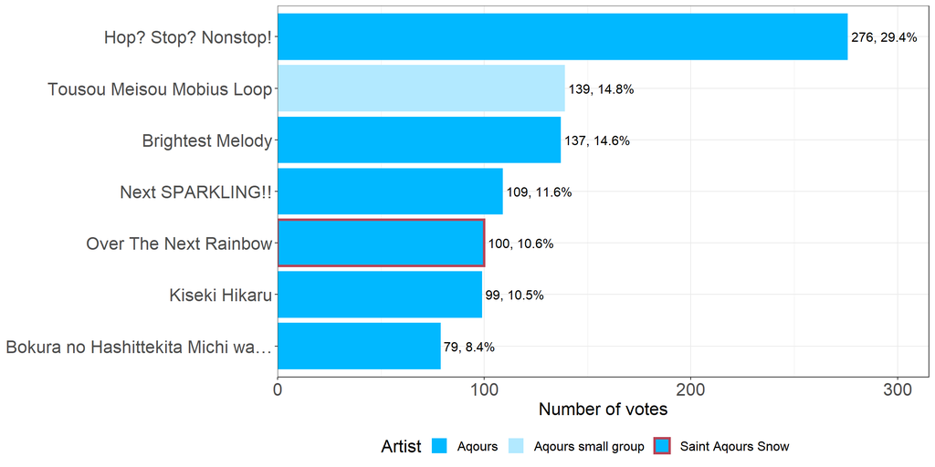

| Number of ballots: | 549 |
| --- | --- |
| Number of votes: | 939 |
| Vote limit: | 2 |

## 4. Which are your favorite non-insert Aqours songs?

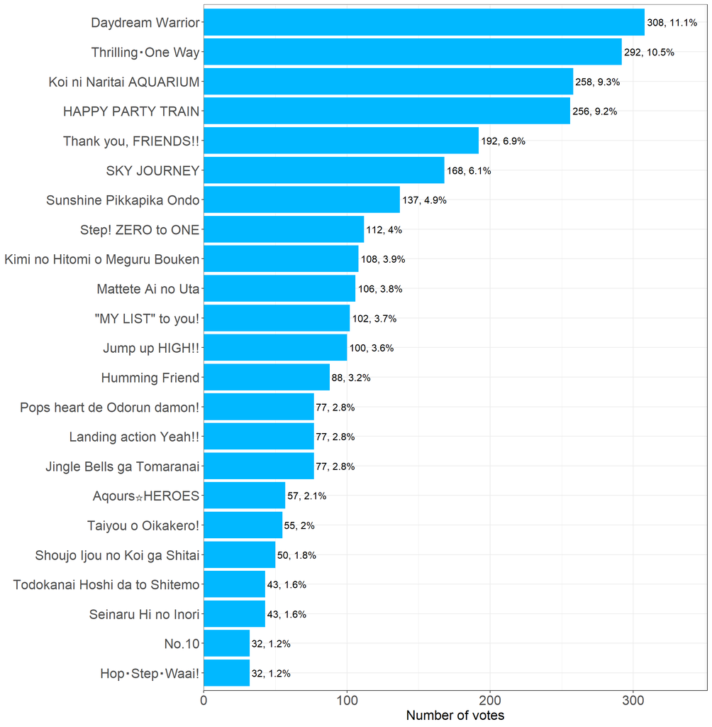

| Number of ballots: | 685 |
| --- | --- |
| Number of votes: | 2770 |
| Vote limit: | 5 |

## 5. Which are your favorite Guilty Kiss songs?

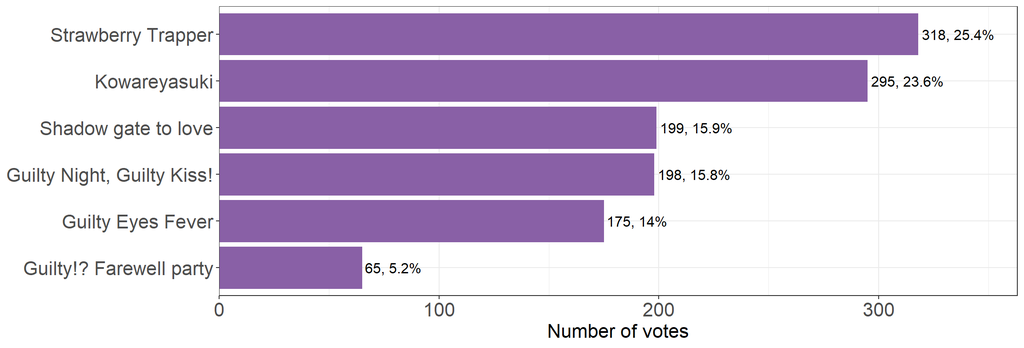

| Number of ballots: | 677 |
| --- | --- |
| Number of votes: | 1250 |
| Vote limit: | 2 |

## 6. Which are your favorite AZALEA songs?

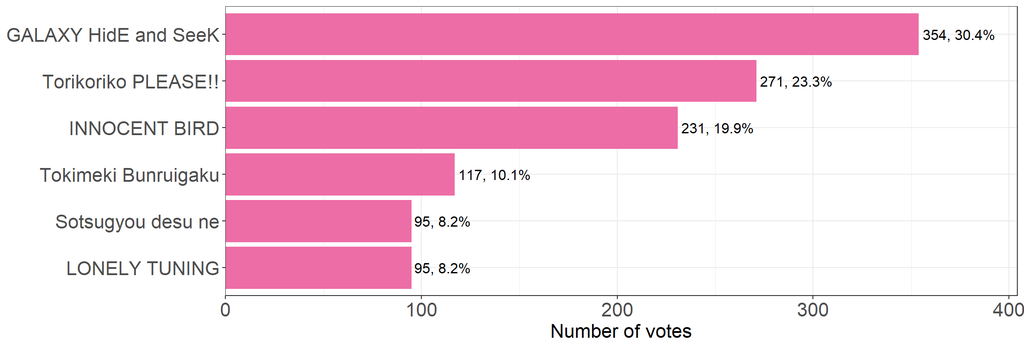

| Number of ballots: | 647 |
| --- | --- |
| Number of votes: | 1163 |
| Vote limit: | 2 |

## 7. Which are your favorite CYaRon! songs?

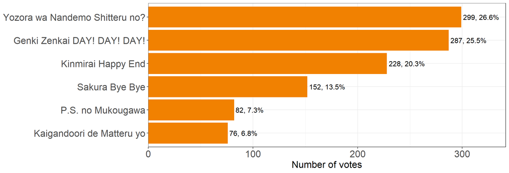

| Number of ballots: | 640 |
| --- | --- |
| Number of votes: | 1124 |
| Vote limit: | 2 |

## 8. Which are your favorite duets/trios?

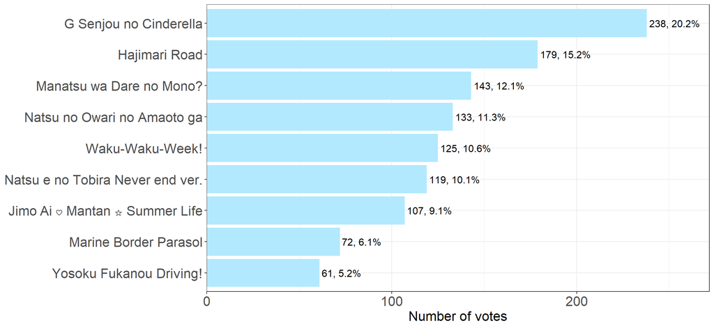

| Number of ballots: | 647 |
| --- | --- |
| Number of votes: | 1177 |
| Vote limit: | 2 |

## 9. Which are your favorite solo songs?

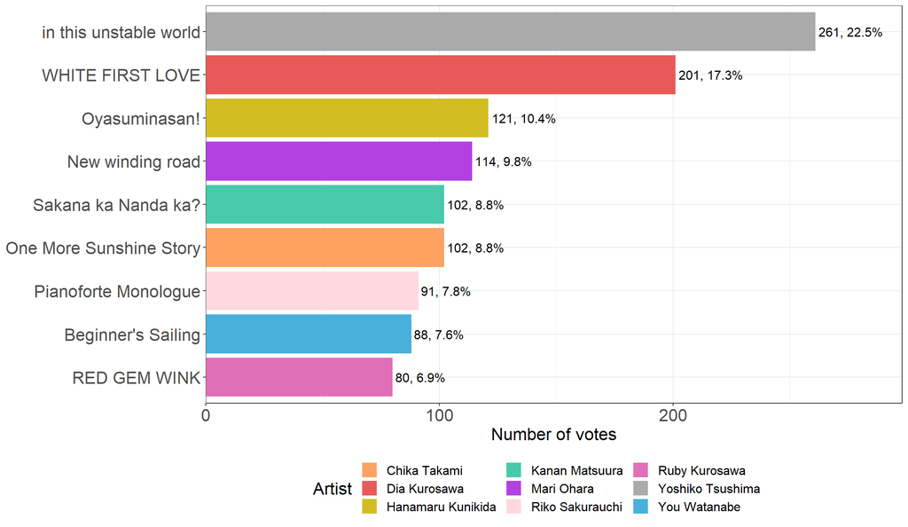

| Number of ballots: | 642 |
| --- | --- |
| Number of votes: | 1160 |
| Vote limit: | 2 |

## 10. Which is your favorite Saint Snow song?

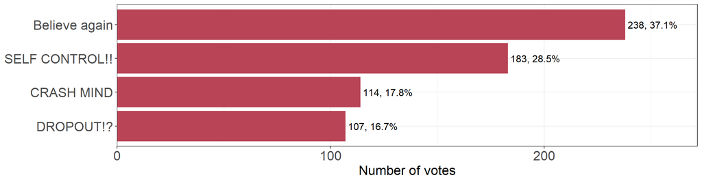

| Number of ballots: | 642 |
| --- | --- |
| Number of votes: | 642 |
| Vote limit: | 1 |

## 11. Out of every song from this section, which is your favorite?

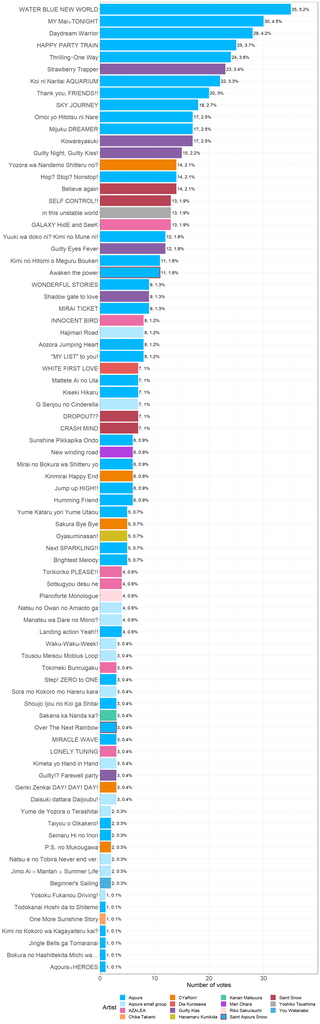

| Number of ballots: | 667 |
| --- | --- |
| Number of votes: | 667 |
| Vote limit: | 1 |

## 12. Which is your favorite MV?

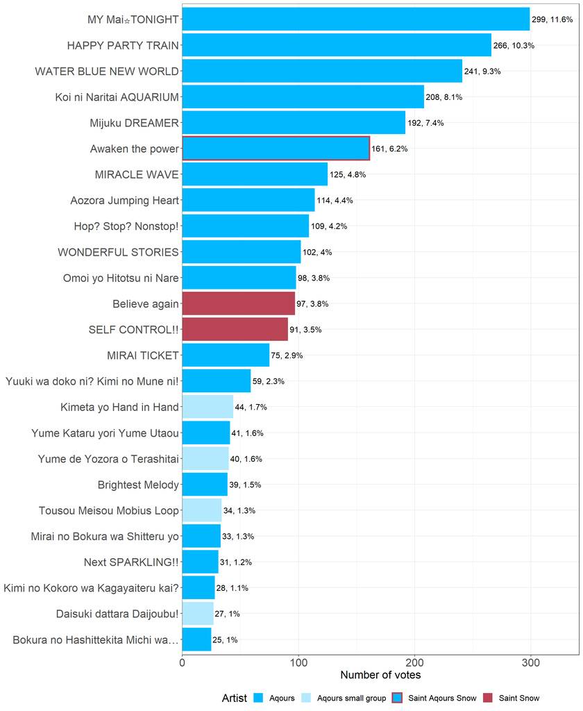

| Number of ballots: | 633 |
| --- | --- |
| Number of votes: | 2579 |
| Vote limit: | 6 |

## 13. Which Aqours member is your favorite singer?

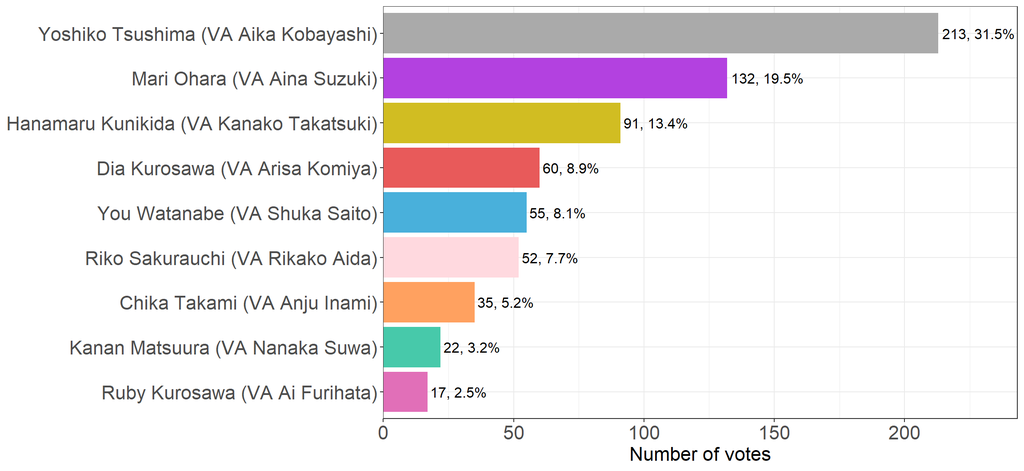

| Number of ballots: | 677 |
| --- | --- |
| Number of votes: | 677 |
| Vote limit: | 1 |

# Section 3: PERFECT Dream Project

## 1. Which is your favorite PERFECT Dream Project song?

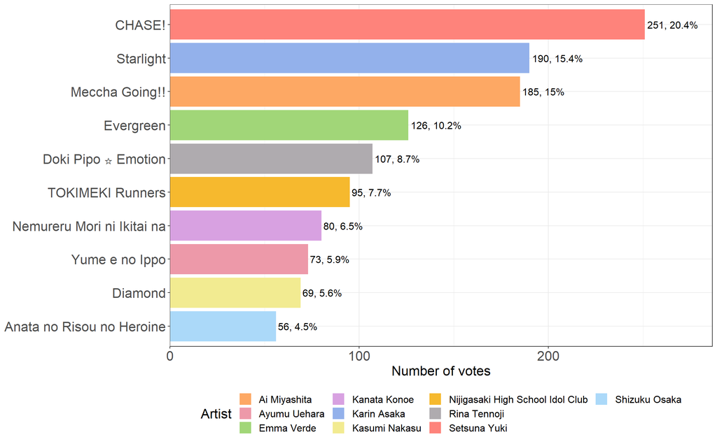

| Number of ballots: | 555 |
| --- | --- |
| Number of votes: | 1232 |
| Vote limit: | 3 |

## 2. Which PERFECT Dream Project member is your favorite singer?

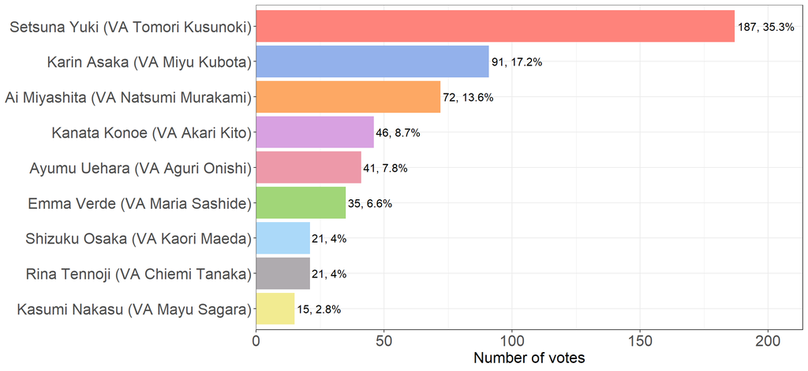

| Number of ballots: | 529 |
| --- | --- |
| Number of votes: | 529 |
| Vote limit: | 1 |

# Some random observations

## Responses with the most votes

### By raw vote total

| Response | Question | Votes |
| --- | --- | --- |
| PSYCHIC FIRE | Which are your favorite BiBi songs? | 496 |
| Snow halation | Which are your favorite µ’s songs from Love Live! School Idol Project Season 2? | 478 |
| MY Mai☆TONIGHT | Which are your favorite Aqours songs from Love Live! Sunshine!! season 2? | 388 |
| Shocking Party | Which is your favorite A-RISE song? | 380 |
| NO EXIT ORION | Which are your favorite Printemps songs? | 372 |
| soldier game | Which are your favorite Love Live! School Idol Project small group songs? | 370 |
| START:DASH!! | Which are your favorite µ’s songs from Love Live! School Idol Project season 1? | 369 |
| Cutie Panther | Which are your favorite BiBi songs? | 364 |
| GALAXY HidE and SeeK | Which are your favorite AZALEA songs? | 354 |
| Snow halation | Which is your favorite Love Live! School Idol Project MV? | 334 |

### By adjusted vote total (Votes/Average number of votes per respondent)

| Response | Question | Adjusted votes |
| --- | --- | --- |
| Shocking Party | Which is your favorite A-RISE song? | 414.60 |
| Private Wars | Which is your favorite A-RISE song? | 304.40 |
| Snow halation | Which are your favorite µ’s songs from Love Live! School Idol Project Season 2? | 266.83 |
| Believe again | Which is your favorite Saint Snow song? | 266.55 |
| Setsuna Yuki (VA Tomori Kusunoki) | Which PERFECT Dream Project member is your favorite singer? | 254.16 |
| Yoshiko Tsushima (VA Aika Kobayashi) | Which Aqours member is your favorite singer? | 226.21 |
| MY Mai☆TONIGHT | Which are your favorite Aqours songs from Love Live! Sunshine!! season 2? | 225.89 |
| GALAXY HidE and SeeK | Which are your favorite AZALEA songs? | 218.85 |
| Hop? Stop? Nonstop! | Which are your favorite Aqours songs from Love Live! The School Idol Movie: Over The Rainbow? | 211.34 |
| START:DASH!! | Which are your favorite µ’s songs from Love Live! School Idol Project season 1? | 205.35 |

- The average number of votes per respondent for a given question takes into account a respondent even if the respondent did not answer the question. The respondent is merely counted as providing 0 votes for the question. This interpretation has the caveat that this respondent answered at least one other question (or else the respondent would have already been removed as a blank ballot).

## Responses with the highest percentages

| Response | Question | Percentage |
| --- | --- | --- |
| Shocking Party | Which is your favorite A-RISE song? | 57.66 |
| Private Wars | Which is your favorite A-RISE song? | 42.34 |
| Snow halation | Which are your favorite µ’s songs from Love Live! School Idol Project Season 2? | 37.11 |
| Believe again | Which is your favorite Saint Snow song? | 37.07 |
| Setsuna Yuki (VA Tomori Kusunoki) | Which PERFECT Dream Project member is your favorite singer? | 35.35 |
| Yoshiko Tsushima (VA Aika Kobayashi) | Which Aqours member is your favorite singer? | 31.46 |
| MY Mai☆TONIGHT | Which are your favorite Aqours songs from Love Live! Sunshine!! season 2? | 31.42 |
| GALAXY HidE and SeeK | Which are your favorite AZALEA songs? | 30.44 |
| Hop? Stop? Nonstop! | Which are your favorite Aqours songs from Love Live! The School Idol Movie: Over The Rainbow? | 29.39 |
| START:DASH!! | Which are your favorite µ’s songs from Love Live! School Idol Project season 1? | 28.56 |

## Responses with the largest winning margins by percentage

| Response | Question | Margin (%) |
| --- | --- | --- |
| Snow halation | Which are your favorite µ’s songs from Love Live! School Idol Project Season 2? | +19.6 |
| Setsuna Yuki (VA Tomori Kusunoki) | Which PERFECT Dream Project member is your favorite singer? | +18.1 |
| Shocking Party | Which is your favorite A-RISE song? | +15.3 |
| START:DASH!! | Which are your favorite µ’s songs from Love Live! School Idol Project season 1? | +15.1 |
| Hop? Stop? Nonstop! | Which are your favorite Aqours songs from Love Live! The School Idol Movie: Over The Rainbow? | +14.6 |
| Yoshiko Tsushima (VA Aika Kobayashi) | Which Aqours member is your favorite singer? | +12 |
| MY Mai☆TONIGHT | Which are your favorite Aqours songs from Love Live! Sunshine!! season 2? | +10.9 |
| Believe again | Which is your favorite Saint Snow song? | +8.6 |
| soldier game | Which are your favorite Love Live! School Idol Project small group songs? | +7.7 |
| GALAXY HidE and SeeK | Which are your favorite AZALEA songs? | +7.1 |

## Questions with the most/fewest number of ballots

### Most

| Question | Ballots |
| --- | --- |
| Which are your favorite µ’s songs from Love Live! School Idol Project Season 2? | 707 |
| Which µ’s member is your favorite singer? | 706 |
| Which are your favorite non-insert µ’s songs? | 705 |
| Which are your favorite µ’s songs from Love Live! School Idol Project season 1? | 704 |
| Which are your favorite BiBi songs? | 704 |
| Which are your favorite µ’s songs from Love Live! The School Idol Movie? | 700 |
| Which are your favorite Love Live! School Idol Project small group songs? | 692 |

### Fewest

| Question | Ballots |
| --- | --- |
| Which PERFECT Dream Project member is your favorite singer? | 529 |
| Which are your favorite Aqours songs from Love Live! The School Idol Movie: Over The Rainbow? | 549 |
| Which is your favorite PERFECT Dream Project song? | 555 |
| Which is your favorite Love Live! School Idol Project MV? | 629 |
| Which is your favorite Love Live! Sunshine!! MV? | 633 |
| Which are your favorite CYaRon! songs? | 640 |
| Which are your favorite Love Live! Sunshine!! solo songs? | 642 |

## Average number of votes per respondent by question

| Question | Avg votes | Vote limit | Response rate (%) |
| --- | --- | --- | --- |
| Which are your favorite µ’s songs from Love Live! School Idol Project season 1? | 1.80 | 2 | 89.85 |
| Which are your favorite µ’s songs from Love Live! School Idol Project Season 2? | 1.79 | 2 | 89.57 |
| Which are your favorite µ’s songs from Love Live! The School Idol Movie? | 1.77 | 2 | 88.53 |
| Which are your favorite non-insert µ’s songs? | 4.42 | 6 | 73.67 |
| Which are your favorite BiBi songs? | 2.60 | 3 | 86.65 |
| Which are your favorite lily white songs? | 2.47 | 3 | 82.38 |
| Which are your favorite Printemps songs? | 2.33 | 3 | 77.56 |
| Which are your favorite Love Live! School Idol Project small group songs? | 2.61 | 3 | 87.02 |
| Which are your favorite Love Live! School Idol Project solo songs? | 4.27 | 5 | 85.37 |
| Which is your favorite A-RISE song? | 0.92 | 1 | 91.66 |
| Out of every song from Love Live! School Idol Project, which is your favorite? | 0.94 | 1 | 94.02 |
| Which is your favorite Love Live! School Idol Project MV? | 3.60 | 6 | 59.94 |
| Which µ’s member is your favorite singer? | 0.98 | 1 | 98.19 |
| Which are your favorite Aqours songs from Love Live! Sunshine!! season 1? | 1.70 | 2 | 85.19 |
| Which are your favorite Aqours songs from Love Live! Sunshine!! season 2? | 1.72 | 2 | 85.88 |
| Which are your favorite Aqours songs from Love Live! The School Idol Movie: Over The Rainbow? | 1.31 | 2 | 65.30 |
| Which are your favorite non-insert Aqours songs? | 3.85 | 5 | 77.05 |
| Which are your favorite Guilty Kiss songs? | 1.74 | 2 | 86.93 |
| Which are your favorite AZALEA songs? | 1.62 | 2 | 80.88 |
| Which are your favorite CYaRon! songs? | 1.56 | 2 | 78.16 |
| Which are your favorite Love Live! Sunshine!! duets/trios? | 1.64 | 2 | 81.85 |
| Which are your favorite Love Live! Sunshine!! solo songs? | 1.61 | 2 | 80.67 |
| Which is your favorite Saint Snow song? | 0.89 | 1 | 89.29 |
| Out of every song from Love Live! Sunshine!!, which is your favorite? | 0.93 | 1 | 92.77 |
| Which is your favorite Love Live! Sunshine!! MV? | 3.59 | 6 | 59.78 |
| Which Aqours member is your favorite singer? | 0.94 | 1 | 94.16 |
| Which is your favorite PERFECT Dream Project song? | 1.71 | 3 | 57.12 |
| Which PERFECT Dream Project member is your favorite singer? | 0.74 | 1 | 73.57 |

- The average number of votes per respondent for a given question takes into account a respondent even if the respondent did not answer the question. The respondent is merely counted as providing 0 votes for the question. This interpretation has the caveat that this respondent answered at least one other question (or else the respondent would have already been removed as a blank ballot).

# Song Index

“MY LIST” to you!: 2.4, 2.11

？←HEARTBEAT: 1.3, 1.11, 1.12

A-NO-NE-GA-N-BA-RE!: 1.6, 1.11

after school NAVIGATORS: 1.8, 1.11

Ai wa Taiyou Ja Nai?: 1.9

Aishiteru Banzai!: 1.1, 1.11

Aki no Anata no Sora Tooku: 1.6, 1.11

Anata no Risou no Heroine: 3.1

Anemone heart: 1.8

Angelic Angel: 1.3, 1.11, 1.12

Aozora Jumping Heart: 2.1, 2.11, 2.12

Aqours☆HEROES: 2.4, 2.11

Arashi no Naka no Koi dakara: 1.4, 1.11

Arifureta Kanashimi no Hate: 1.9, 1.11

Awaken the power: 2.2, 2.11, 2.12

baby maybe Koi no Button: 1.4, 1.11

Beat in Angel: 1.8, 1.11

Beginner’s Sailing: 2.9, 2.11

Believe again: 2.10, 2.11, 2.12

Binetsu Kara Mystery: 1.6, 1.11

Blueberry♥Train: 1.9, 1.11

Bokura no Hashittekita Michi wa…: 2.3, 2.11, 2.12

Bokura no LIVE Kimi to no LIFE: 1.1, 1.11, 1.12

Bokura wa Ima no Naka de: 1.1, 1.11, 1.12

Bokutachi wa Hitotsu no Hikari: 1.3, 1.11, 1.12

Brightest Melody: 2.3, 2.11, 2.12

CHASE!: 3.1

CheerDay CheerGirl!: 1.7, 1.11

COLORFUL VOICE: 1.4, 1.11

CRASH MIND: 2.10, 2.11

Cutie Panther: 1.5, 1.11

Daisuki dattara Daijoubu!: 2.1, 2.11, 2.12

Dancing stars on me!: 1.2, 1.11, 1.12

Daring!!: 1.9, 1.11

Datte Datte Aa Mujou: 1.4, 1.11

Daydream Warrior: 2.4, 2.11

Diamond: 3.1

Diamond Princess no Yuuutsu: 1.5, 1.11

Doki Pipo ☆ Emotion: 3.1

Donna Toki mo Zutto: 1.2, 1.11, 1.12

Dreamin’ Go! Go!!: 1.4, 1.11

DROPOUT!?: 2.10, 2.11

Eien Friends: 1.7, 1.11

ENDLESS PARADE: 1.4, 1.11

Evergreen: 3.1

Futari Happiness: 1.6

Future style: 1.3, 1.11, 1.12

Fuyu ga Kureta Yokan: 1.5, 1.11

G Senjou no Cinderella: 2.8, 2.11

GALAXY HidE and SeeK: 2.6, 2.11

Garasu no Hanazono: 1.8, 1.11

Genki Zenkai DAY! DAY! DAY!: 2.7, 2.11

Guilty Eyes Fever: 2.5, 2.11

Guilty Night, Guilty Kiss!: 2.5, 2.11

Guilty!? Farewell party: 2.5, 2.11

Hajimari Road: 2.8, 2.11

Hane wa Shitte Shimatta no?: 1.9

Happy maker!: 1.2, 1.11, 1.12

HAPPY PARTY TRAIN: 2.4, 2.11, 2.12

HEART to HEART!: 1.4, 1.11

Hello, Hoshi o Kazoete: 1.3, 1.11, 1.12

Himitsu to Hanazono: 1.9

Hop? Stop? Nonstop!: 2.3, 2.11, 2.12

Hop・Step・Waai!: 2.4

Humming Friend: 2.4, 2.11

I’ll smile for yours: 1.9

in this unstable world: 2.9, 2.11

INNOCENT BIRD: 2.6, 2.11

Jimo Ai ♡ Mantan ☆ Summer Life: 2.8, 2.11

Jingle Bells ga Tomaranai: 2.4, 2.11

Jump up HIGH!!: 2.4, 2.11

Junai Lens: 1.9, 1.11

Kaguya no Shiro de Odoritai: 1.4, 1.11

Kaigandoori de Matteru yo: 2.7

Kaku mo Yuubi na Hi to Narite: 1.9

Kakumei desu ne? Kamisama!: 1.8

Kimeta yo Hand in Hand: 2.1, 2.11, 2.12

Kimi no Hitomi o Meguru Bouken: 2.4, 2.11

Kimi no Kokoro wa Kagayaiteru kai?: 2.2, 2.11, 2.12

Kimi no Kuse ni!: 1.6, 1.11

Kinmirai Happy End: 2.7, 2.11

KiRa-KiRa Sensation!: 1.2, 1.11, 1.12

Kiseki Hikaru: 2.3, 2.11

Kitto Seishun ga Kikoeru: 1.1, 1.11, 1.12

Kodoku na Heaven: 1.9, 1.11

Kodoku no Kairou: 1.9

Koi ni Naritai AQUARIUM: 2.4, 2.11, 2.12

Koi no Signal Rin rin rin!: 1.9, 1.11

Koko de Matteru yo: 1.9

Kokuhaku Biyori, desu!: 1.8

Korekara: 1.4, 1.11

Korekara no Someday: 1.1, 1.12

Kowareyasuki: 2.5, 2.11

Kururin MIRACLE: 1.9, 1.11

Landing action Yeah!!: 2.4, 2.11

Listen to my heart!!: 1.8, 1.11

LONELIEST BABY: 1.4, 1.11

LONELY TUNING: 2.6, 2.11

Love marginal: 1.7, 1.11

Love Novels: 1.5, 1.11

Love wing bell: 1.2, 1.11, 1.12

LOVELESS WORLD: 1.4, 1.11

Mahoutsukai Hajimemashita!: 1.9, 1.11

Manatsu wa Dare no Mono?: 2.8, 2.11

Marine Border Parasol: 2.8

Mattete Ai no Uta: 2.4, 2.11

Meccha Going!!: 3.1

Mermaid festa vol.1: 1.4, 1.11

Mermaid festa vol.2 ~Passionate~: 1.8, 1.11

Mi wa µ'sic no Mi: 1.4

Mijuku DREAMER: 2.1, 2.11, 2.12

MIRACLE WAVE: 2.2, 2.11, 2.12

Mirai no Bokura wa Shitteru yo: 2.2, 2.11, 2.12

MIRAI TICKET: 2.1, 2.11, 2.12

Mogyutto “love” de Sekkin Chuu!: 1.4, 1.11, 1.12

MOMENT RING: 1.4, 1.11

Moshimo Kara Kitto: 1.9, 1.11

Mou Hitori Ja Nai yo: 1.9, 1.11

MUSEUM de Dou Shitai?: 1.7, 1.11

Music S.T.A.R.T!!: 1.4, 1.11, 1.12

MY Mai☆TONIGHT: 2.2, 2.11, 2.12

Natsu e no Tobira Never end ver.: 2.8, 2.11

Natsu no Owari no Amaoto ga: 2.8, 2.11

Natsu, Owaranai de.: 1.5, 1.11

Natsuiro Egao de 1,2,Jump!: 1.4, 1.11, 1.12

Nawatobi: 1.9, 1.11

Nemureru Mori ni Ikitai na: 3.1

NEURON,NEURON!!: 1.9

New winding road: 2.9, 2.11

Next SPARKLING!!: 2.3, 2.11, 2.12

Nightingale Love Song: 1.7

Niko puri♥Joshi dou: 1.9, 1.11

No brand girls: 1.1, 1.11, 1.12

NO EXIT ORION: 1.7, 1.11

No.10: 2.4

Oh,Love&Peace!: 1.2, 1.11

Omoi yo Hitotsu ni Nare: 2.1, 2.11, 2.12

Omoide Ijou ni Naritakute: 1.6

Onaji Hoshi ga Mitai: 1.6, 1.11

One More Sunshine Story: 2.9, 2.11

Otohime Heart de Love Kyuuden: 1.6, 1.11

Otome Shiki Ren’ai Juku: 1.8

Over The Next Rainbow: 2.3, 2.11

Oyasuminasan!: 2.9, 2.11

P.S. no Mukougawa: 2.7, 2.11

Paradise Live: 1.4, 1.11

Pianoforte Monologue: 2.9, 2.11

Pops heart de Odorun damon!: 2.4

Private Wars: 1.10, 1.11, 1.12

PSYCHIC FIRE: 1.5, 1.11

Pure girls project: 1.7, 1.11

Puwa Puwa-O!: 1.7, 1.11

RED GEM WINK: 2.9

Ruteshi Kisuki Shiteru: 1.4, 1.11

Saitei de Saikou no Paradiso: 1.5, 1.11

Sakana ka Nanda ka?: 2.9, 2.11

Sakkaku CROSSROADS: 1.5, 1.11

Sakura Bye Bye: 2.7, 2.11

Sayounara e Sayonara!: 1.4, 1.11

Seinaru Hi no Inori: 2.4, 2.11

SELF CONTROL!!: 2.10, 2.11, 2.12

Senkou Resolution: 1.9

SENTIMENTAL StepS: 1.4

Shadow gate to love: 2.5, 2.11

Shangri-La Shower: 1.4, 1.11

Shiawase Iki no SMILING!: 1.9

Shiranai Love*Oshiete Love: 1.6, 1.11

Shocking Party: 1.10, 1.11, 1.12

Shoujo Ijou no Koi ga Shitai: 2.4, 2.11

Shunjou Romantic: 1.6, 1.11

Silent tonight: 1.5, 1.11

SKY JOURNEY: 2.4, 2.11

Snow halation: 1.2, 1.11, 1.12

soldier game: 1.8, 1.11

Someday of my life: 1.9

Sora mo Kokoro mo Hareru kara: 2.2, 2.11

Sore wa Bokutachi no Kiseki: 1.2, 1.12

Soshite Saigo no Page ni wa: 1.4, 1.11

Sotsugyou desu ne: 2.6, 2.11

Spicaterrible: 1.9, 1.11

Starlight: 3.1

START:DASH!!: 1.1, 1.11, 1.12

Step! ZERO to ONE: 2.4, 2.11

Storm in Lover: 1.8, 1.11

Strawberry Trapper: 2.5, 2.11

Suki desu ga Suki desu ka?: 1.8, 1.11

SUNNY DAY SONG: 1.3, 1.11, 1.12

Sunshine Pikkapika Ondo: 2.4, 2.11

Super LOVE=Super LIVE!: 1.4, 1.11

Susume→Tomorrow: 1.1, 1.11, 1.12

sweet&sweet holiday: 1.7

Taiyou o Oikakero!: 2.4, 2.11

Takaramonozu: 1.4, 1.11

Thank you, FRIENDS!!: 2.4, 2.11

Thrilling・One Way: 2.4, 2.11

Todokanai Hoshi da to Shitemo: 2.4, 2.11

Tokimeki Bunruigaku: 2.6, 2.11

TOKIMEKI Runners: 3.1

Torikoriko PLEASE!!: 2.6, 2.11

Tousou Meisou Mobius Loop: 2.3, 2.11, 2.12

Trouble Busters: 1.5, 1.11

UNBALANCED LOVE: 1.7, 1.11

Waku-Waku-Week!: 2.8, 2.11

WAO-WAO Powerful day!: 1.7

Watashitachi wa Mirai no Hana: 1.9, 1.11

WATER BLUE NEW WORLD: 2.2, 2.11, 2.12

WHITE FIRST LOVE: 2.9, 2.11

WILD STARS: 1.4

Wonder zone: 1.1, 1.11, 1.12

Wonderful Rush: 1.4, 1.11, 1.12

WONDERFUL STORIES: 2.2, 2.11, 2.12

Yosoku Fukanou Driving!: 2.8, 2.11

Yozora wa Nandemo Shitteru no?: 2.7, 2.11

Yume de Yozora o Terashitai: 2.1, 2.11, 2.12

Yume e no Ippo: 3.1

Yume Kataru yori Yume Utaou: 2.1, 2.11, 2.12

Yume Naki Yume wa Yume ja nai: 1.9

Yume no Tobira: 1.2, 1.11, 1.12

Yume☆ONCE AGAIN: 1.9

Yuujou No Change: 1.4, 1.11

Yuuki no Reason: 1.9, 1.11

Yuuki wa doko ni? Kimi no Mune ni!: 2.2, 2.11, 2.12

Zurui yo Magnetic today: 1.8, 1.11

# References

- a-large-bee. “2019 Song Popularity Poll Results.” r/SchoolIdolFestival. Last modified July 9, 2019. Accessed July 9, 2019. https://www.reddit.com/r/SchoolIdolFestival/comments/cb70qb/2019_song_popularity_poll_results.
- Love Live! Wikia. Accessed July 12, 2019. https://love-live.fandom.com.